# Applying multicate

Kyungeun Jeon, Carly Brantner, Daniel Obeng, Elizabeth Stuart

2025-10-14

This guide provides an introduction to applying the `multicate` package in health data analyses. The explanations below are based on the original paper that is based on for development of this package: *Comparison of methods that combine multiple randomized trials to estimate heterogeneous treatment effects. Statistics in medicine (Brantner et al., 2024)*.[^1] The detailed github code and readme are in this link(https://github.com/dobengjhu/multicate).

# Application

## 1) Load packages

To get started, install and load the `multicate` package using either `install.packages(multicate)` or `pak::pak("dobengjhu/multicate")`. To explore the functionality of the package, you can examine the sample dataset `dummy_tbl`. This dataset includes three previously conducted trials comparing the same two treatments. It contains:

- An outcome variable called `response`
- A treatment indicator `tx`
- Five signal covariates (`var` to `var5`) that may act as effect modifiers

You can view a summary of the dataset with `summary(dummy_tbl)`.

In this document, we used the packages as follows.

```r
# 1) Install multicate package
#install.packages("multicate")
#pak::pak("dobengjhu/multicate")
library(multicate)

#2) Additional packages for data cleansing
library(tibble)
#install.packages("tableone")
library(tableone)
library(tidyverse)
#install.packages("fastDummies")  # if not already installed
library(fastDummies)
#install.packages("kableExtra")
library(kableExtra)
#install.packages("performance")
library(performance)
```

## 2) RHC dataset

In this example, we use data from a study of Right Heart Catheterization (RHC), a diagnostic procedure used to measure cardiac function in critically ill patients. While RHC can guide urgent and ongoing treatment decisions, it also carries a risk of serious complications. The observational dataset originates from Murphy and Cluff (1990), was later reanalyzed by Connors et al. (1996), and has since become a benchmark dataset in causal inference research.

- Data[^2]
- Dictionary[^3]

The dataset (`rhc.xls`) includes information on 5,735 hospitalized adult patients across five U.S. medical centers. The `treatment` variable (column 2) indicates whether RHC was administered within 24 hours of admission (`TRUE` for treatment; `FALSE` for control). The outcome variable of this study is originally `dth30` (column 54), records 30-day post-admission mortality (`TRUE` for death; `FALSE` for survival), but in this example, we set the outcome Glasgow Coma Score (`scoma1` variable) as our continuous coutcome.

Covariate information (column 3 to 53): age, sex, race (black, white, other), years of education,income, type of medical insurance (private, Medicare, Medicaid, private and Medicare, Medicare and Medicaid, or none), primary disease category, secondary disease category, 10 categories of admission diagnosis, activities of daily living (ADL) and Duke Activity Status Index (DASI) 2 weeks before admission, do-not-resuscitate status on day 1 of admission, cancer (none, localized, metastatic), an estimate of the probability of surviving 2 months, acute physiology component of the APACHE III score, Glasgow Coma Score, weight, temperature, mean blood pressure, respiratory rate, heart rate, PaO2=FIO2 ratio, PaCO2, pH, WBC count, hematocrit, sodium, potassium, creatinine, bilirubin, albumin, urine output, 12 categories of comorbidity illness, and whether the patient transferred from another hospital. Since the number of covariates are too big for this demonstration purpose, we will choose a smaller set of covariates in analysis.

To demonstrate the functionality of the `multicate` package in the context of multiple studies, we simulate study membership by arbitrarily dividing the dataset into five groups, treating them as if they came from five distinct medical centers. Although the original dataset does not indicate which patient belongs to which hospital, this simulated structure allows us to explore treatment effect heterogeneity across centers and individual-level covariates.

```r
#Load data
rhc <- read.csv(file="rhc.xls", header=TRUE)
rhc <- rhc %>% mutate(across(where(is.logical), as.numeric))
rhc <- rhc %>% subset(select = c(-ID))
rhc$center <- rep(1:5, each=nrow(rhc)/5)
rhc$center <- as.character(rhc$center)

#Choose covariates to be used for this study
rhc <- rhc %>% select(treatment, center, scoma1,
                      race, ninsclas,
                      hrt1, resp1, bili1, pafi1, aps1, temp1, das2d3pc, sod1, liverhx)
```

| center | treatment | scoma1 | race | ninsclas | hrt1 | resp1 | bili1 | pafi1 | aps1 | temp1 | das2d3pc | sod1 | liverhx |
| --- | --- | --- | --- | --- | --- | --- | --- | --- | --- | --- | --- | --- | --- |
| 1 | 0 | 0 | white | Medicare | 124 | 10 | 1.0097656 | 68.0000 | 46 | 38.69531 | 23.50000 | 145 | 0 |
| 1 | 1 | 0 | white | Private & Medicare | 137 | 38 | 0.6999512 | 218.3125 | 50 | 38.89844 | 14.75195 | 137 | 0 |
| 1 | 1 | 0 | white | Private | 130 | 40 | 1.0097656 | 275.5000 | 82 | 36.39844 | 18.13672 | 146 | 0 |
| 1 | 0 | 0 | white | Private & Medicare | 58 | 26 | 0.3999634 | 156.6562 | 48 | 35.79688 | 22.92969 | 117 | 0 |
| 1 | 1 | 41 | white | Medicare | 125 | 27 | 1.0097656 | 478.0000 | 72 | 34.79688 | 21.05078 | 126 | 0 |
| 1 | 0 | 0 | white | Medicare | 134 | 36 | 1.0097656 | 184.1875 | 38 | 39.19531 | 17.50000 | 138 | 0 |
| 1 | 0 | 26 | white | Private | 135 | 10 | 1.0097656 | 148.7500 | 29 | 39.39844 | 15.40625 | 136 | 0 |
| 1 | 0 | 100 | white | Private | 102 | 34 | 0.8999023 | 240.0000 | 25 | 39.19531 | 29.14453 | 136 | 0 |
| 1 | 0 | 0 | white | Private | 118 | 30 | 1.0998535 | 333.3125 | 47 | 38.39844 | 26.28906 | 136 | 0 |
| 1 | 1 | 0 | white | Medicaid | 141 | 40 | 0.5000000 | 68.0000 | 48 | 38.50000 | 23.25781 | 146 | 0 |

## 3) Data preparation

As described above, the `multicate` package builds on other modeling packages, which require the input data to be fully numeric and free of missing (NA) values. To meet these requirements, we pre-processed the dataset accordingly.

After removing missing values (NA) and simplifying categorical variable levels, we convert all factor and character covariates variables into numeric or dummy variables using `fastDummies` package. The `janitor` package’s function, `janitor::clean_names()` is helpful for standardizing column names by replacing spaces and special characters (e.g., converting `condition_no symptoms` to `condition_no_symptoms`).

This is the table to show how dummy variables are created via `fast_dummies`.

| race_other | race_white | ninsclas_medicare | ninsclas_medicare_medicaid | ninsclas_no_insurance | ninsclas_private | ninsclas_private_medicare |
| --- | --- | --- | --- | --- | --- | --- |
| 0 | 1 | 1 | 0 | 0 | 0 | 0 |
| 0 | 1 | 0 | 0 | 0 | 0 | 1 |
| 0 | 1 | 0 | 0 | 0 | 1 | 0 |
| 0 | 1 | 0 | 0 | 0 | 0 | 1 |
| 0 | 1 | 1 | 0 | 0 | 0 | 0 |

This table is the final table about the data we will use for analysis.

Dictionary of variables used in analysis

[output not shown]

## 4) Choose aggregation and estimation method

### 4-1) Studyindicator

```r
set.seed(100)
cate_mod2 <- estimate_cate(rhc_clean,
                          estimation_method = "causalforest",
                          aggregation_method = "studyindicator",
                          study_col = "center",
                          treatment_col = "treatment",
                          outcome_col = "scoma1",
                          covariate_col = NULL,
                          drop_col = c("race","ninsclas"))
summary_cate_mod2 <- summary(cate_mod2)

#result
#cate_mod2
```

```r
#result summary
summary_cate_mod2
```

```
#>
#> Estimation Method: causalforest
#> Aggregation Method: studyindicator
#>
#> Variable Importance:
#>             hrt1     resp1     bili1      pafi1      aps1      temp1   das2d3pc
#> Value 0.08616683 0.2156197 0.1305946 0.07425747 0.2340573 0.08996657 0.06862788
#>             sod1    liverhx   race_other  race_white ninsclas_medicare
#> Value 0.04009024 0.02242125 0.0003493235 0.002782086       0.002467816
#>       ninsclas_medicare_medicaid ninsclas_no_insurance ninsclas_private
#> Value                  0.0011903           0.004070067      0.005487103
#>       ninsclas_private_medicare   center_1    center_2   center_3    center_4
#> Value               0.005270401 0.00320616 0.003143155 0.00296119 0.002510454
#>          center_5
#> Value 0.004759996
#>
#> Overall ATE:
#>   Estimate Std. Error
#>    -3.4392     0.7547
#>
#> Study-Specific ATE:
#>   Minimum CATE Median CATE Maximum CATE
#> 1       -11.55      -2.735        2.789
#> 2       -11.89      -2.738        2.523
#> 3       -12.25      -2.842        2.693
#> 4       -12.39      -2.959        2.738
#> 5       -11.21      -2.799        2.960
```

### 4-2) Comparison with Study-specific

```r
set.seed(100)
cate_mod <- estimate_cate(rhc_clean,
                          estimation_method = "causalforest",
                          aggregation_method = "studyspecific",
                          study_col = "center",
                          treatment_col = "treatment",
                          outcome_col = "scoma1",
                          covariate_col = NULL,
                          drop_col = c("race","ninsclas"))
summary_cate_mod <- summary(cate_mod)

#result
#cate_mod2
```

```r
#result summary
summary_cate_mod$ate
```

```
#>   Estimate Std. Error
#>   -3.41695         NA
```

```r
summary_cate_mod2$ate
```

```
#>   Estimate Std. Error
#> -3.4391637  0.7546843
```

## 5) Visualization of estimation

### 5-1) Visualization of study-specific

The `plot()` funciton with `estimate_cate()` objects provides five visualizations to help interpret the estiamted CATEs: 1. Histogram of the CATEs, 2. Boxplot of CATEs stratified by study membership, 3. Confidence interval plot shoing 95% confidence intervals for all CATEs, sorted by their estiamted CATEs, 4. Best linear projection (available only when `estimation_method = "causalforest"`), 5. Interpretation tree for visualizing how covariates drive treatment effect heterogeneity.

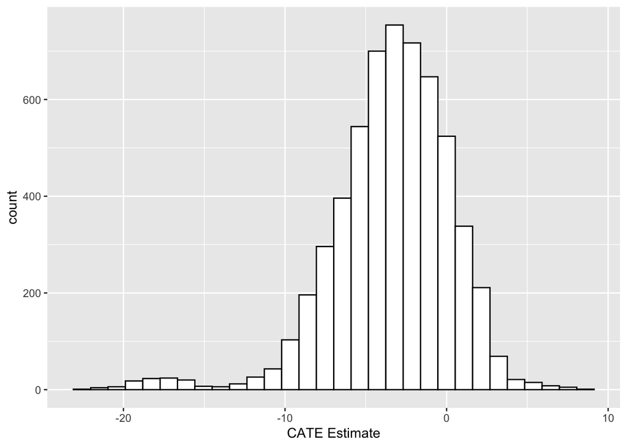

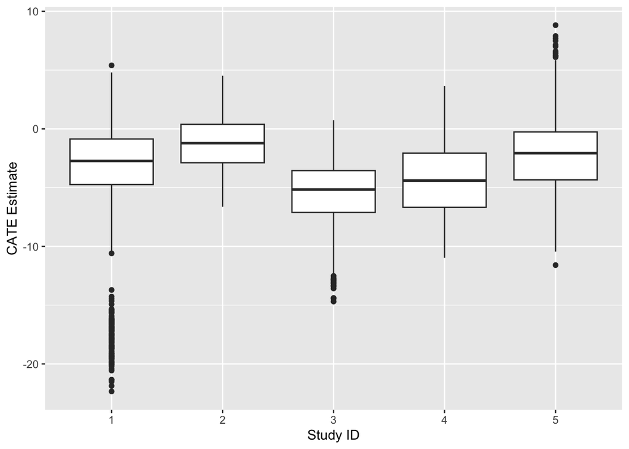

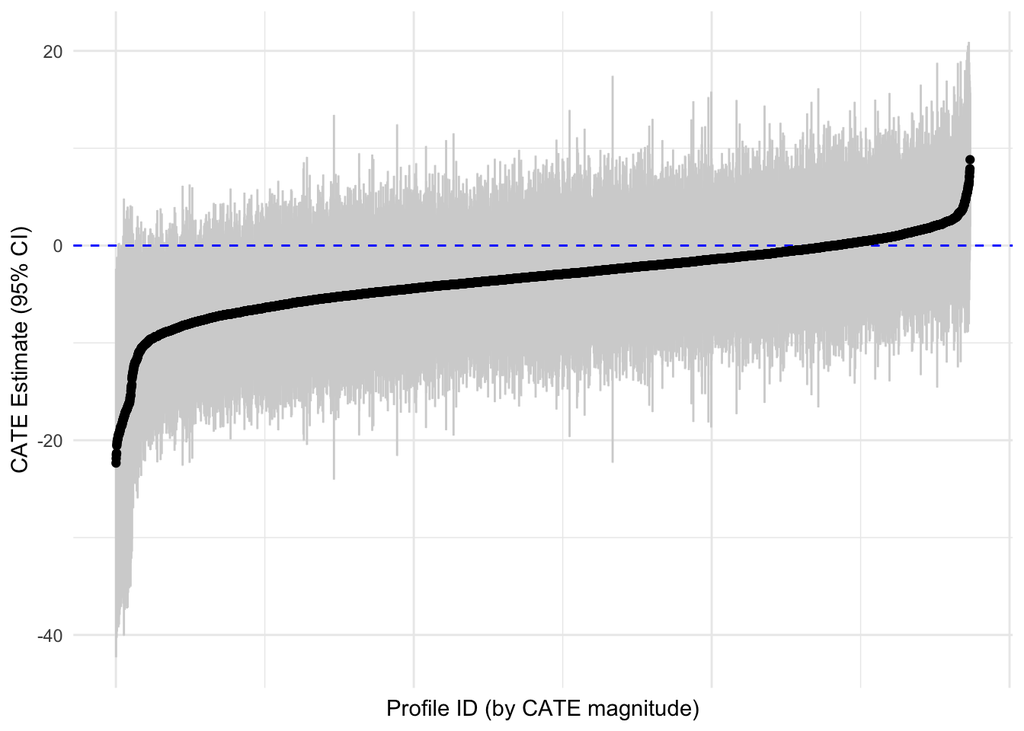

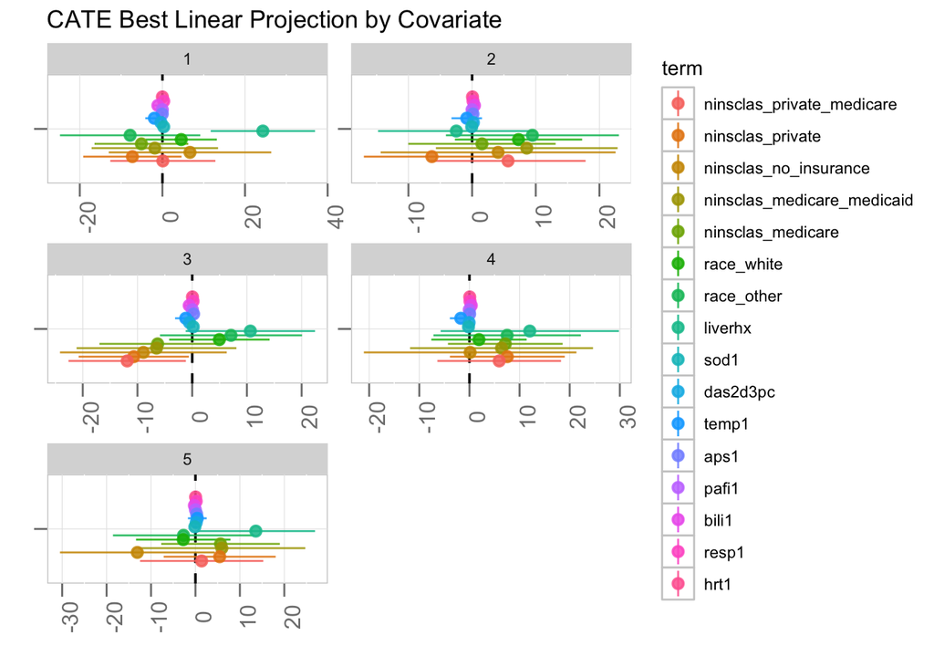

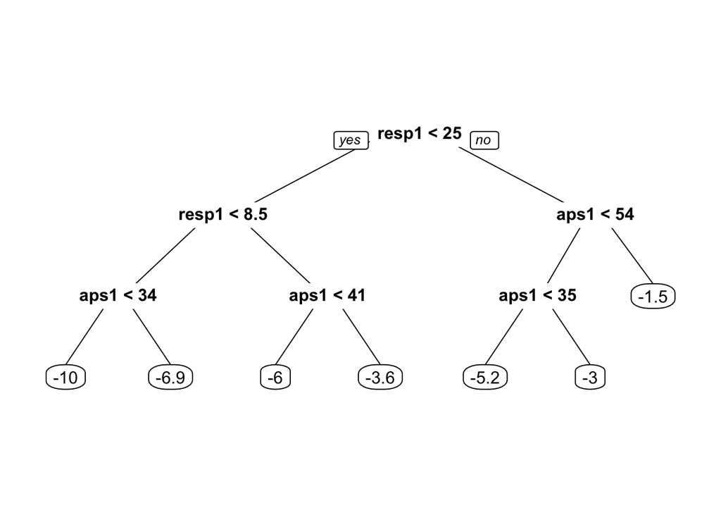

```r
plot(cate_mod)
```

Additionally, the `plot_vteffect()` provides a more focused visualization if you are interested in exploring treatment effect heterogeneity with respect to a specific **continuous** covariate. It plots the estimated CATE (`tau_hat`) for each observation against the selected covariate, allowing you to see how treatment effects vary across its range and across different studies.

For example, if you’re interested in how treatment effects differ by `aps1` across studies, you can specify this variable using the `covariate_name = "aps1"` parameter.

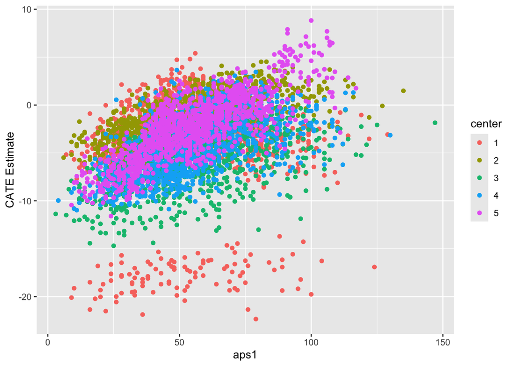

```r
plot_vteffect(cate_mod, covariate_name = "aps1")
```

### 5-2) Visualization of study-indicator

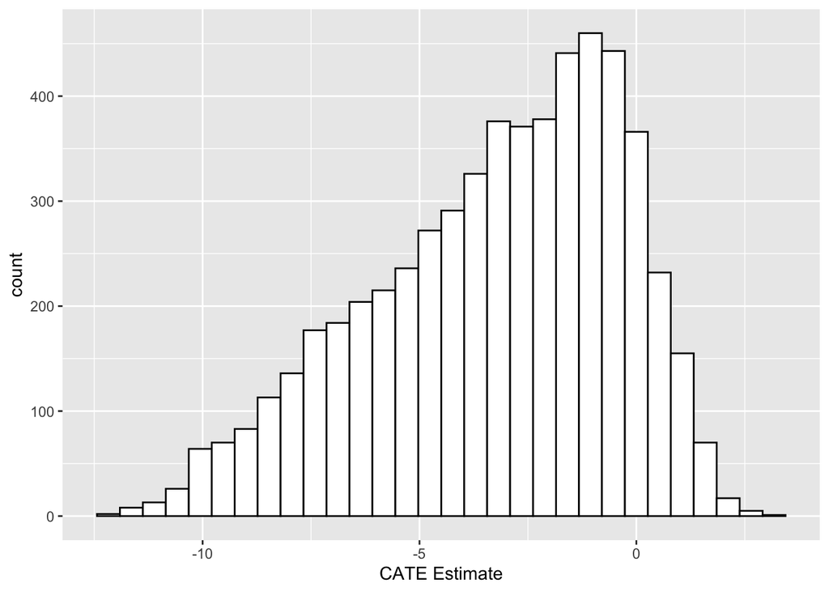

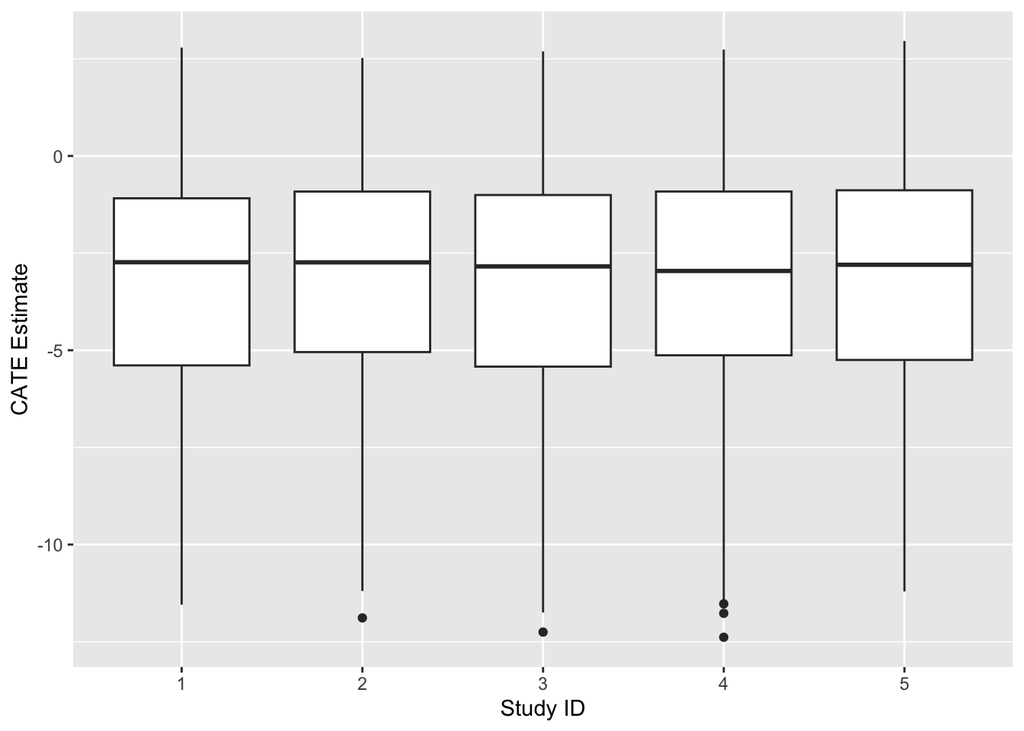

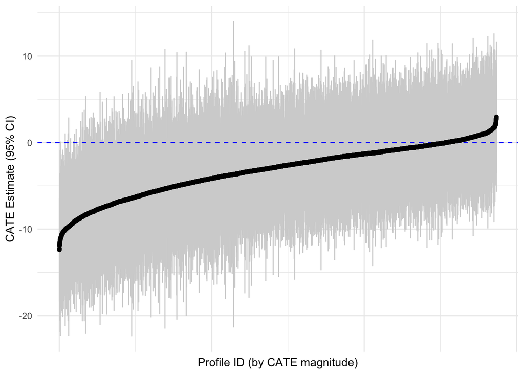

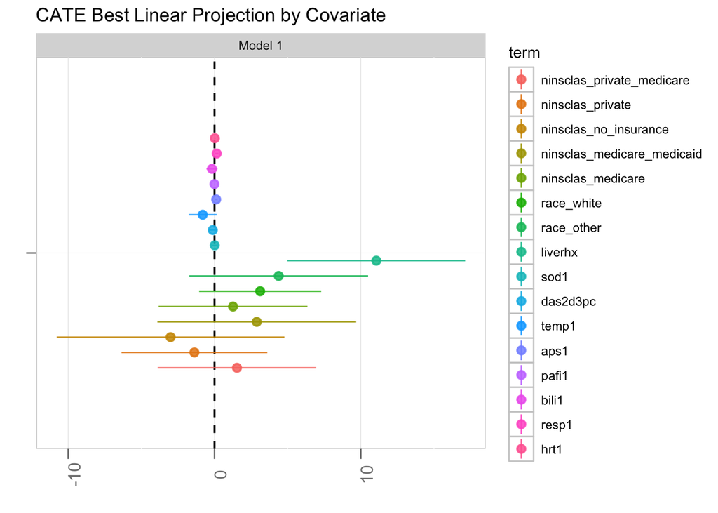

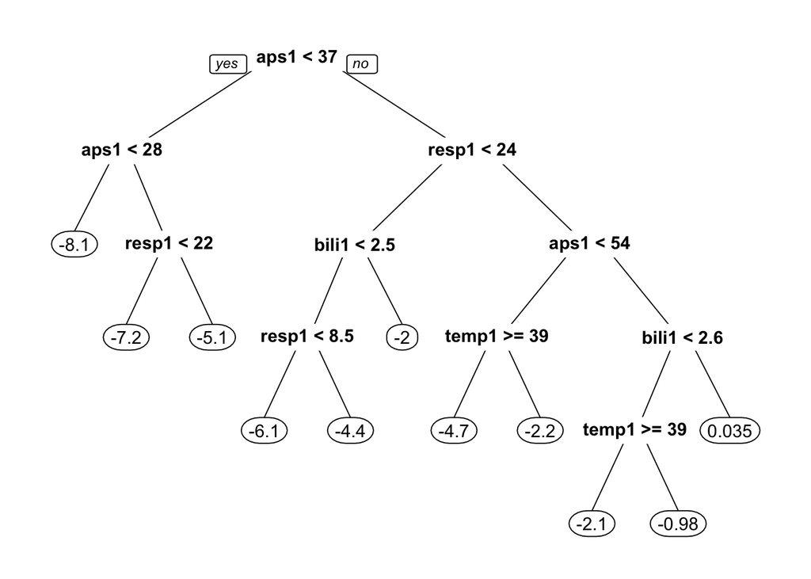

```r
plot(cate_mod2)
```

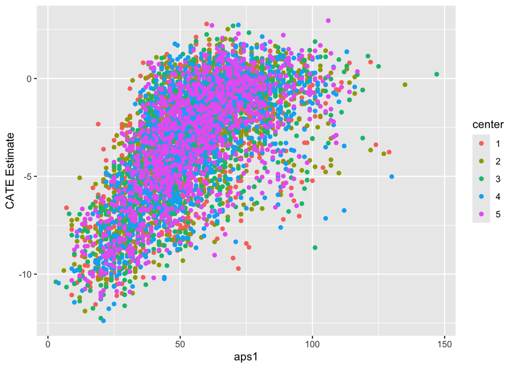

```r
plot_vteffect(cate_mod2, covariate_name = "aps1")
```

# Which dataset is suitable?

#### Q. What kinds of data should I have?

While the primary purpose of this package is for RCTs, but the base dataset can be from randomized controlled trials, observational studies, or a combination of both. Our functions are primarily designed for IPD (Individual Patient Data). The dataset must contain at least **4** key components, a **study indicator variable**, a **treatment indicator variable**, An **outcome variable**, and **covariate variables**.

#### Q. What data format is required?

You should be careful to use which data formats your data has. For this package, the treatment variable should be numeric (e.g. 0 or 1), the study ID should be character (factor is allowed.), and the outcome must be numeric. Note that this package is primarily designed for **continuous outcome**, and covariates should be all numeric.

| Data column | Data format |
| --- | --- |
| treatment | numeric(0,1) |
| studyid | character |
| outcome | numeric |
| covariates | numeric |

##### Q. Can I have missing values?

Packages like `grf` (used for causal_forest) will support missing values in a specific way. The explanations below are from the grf github reference page.[^4]

*Missing values* GRF can handle missing covariate values, meaning that a the input covariate matrix can contain NA in some cells instead of numerical values.

These missing values can be informative, in the sense that the fact that a covariate is missing can be predictive of the unobserved value itself or of the outcome Y, or it can be non-informative. For instance, an individual’s annual income could be missing because this individual is wealthy and prefers to conceal his/her income and this in turn is likely to be predictive, for instance, of the type of housing of this individual.

GRF handles missing values implicitly using the missing incorporated in attributes criterion (MIA; Twala et al., 2008), meaning that as soon as there is a missing value in a variable j, there are three candidate splits for a given threshold.

- split the samples with observed value for j according to the threshold and send all samples with missing value for j to the left,
- split the samples with observed value for j according to the threshold and send all samples with missing value for j to the right,
- send all samples with observed value for j to the left and all samples with missing value for j to the right.

Note that by default, missing values are sent to the left, which implies that if the covariates from the training set are completely observed but there are missing values occurring in a new covariate matrix from the test set, then the prediction functions will not produce an error but simply send the incomplete observations to the left side of the corresponding nodes.

Missing values occur almost inevitably in most applications and the way to handle them depends on the type of analysis one wishes to perform and on the mechanism that generated these missing values. For a broader discussion on treatment effect estimation with missing attributes please see Mayer et al. (2019).

#### Q. What if I have categorical or factor variables in my covariates?

If you need to include factor variables, we recommend the following:

The brief summary of solutions suggested by the grf vignett is as follows:

1. One-hot encoding: Use `fastdummies` to convert categorical variables into dummy variables easily.
- Ensure that values do not contain spaces or special characters. For example, convert ‘study 1’ to ‘study_1’.
2. Means encoding: Use the `sufrep` package for target/means encoding.
3. Oridinal encoding: If your categorical variable has a natural order (e.g. months), encode it as a numeric variable accordingly.

See the `grf` vignette on categorical inputs for mode deail.[^5]

#### Q. I applied one-hot encoding but it is still not working-Why?

Ensure that the column names or formulas passed to estimate_cate() do not contain spaces or logical connectors (like ‘and’). The `janitor` package is helpful for cleaning column names by replacing spaces with underscores (e.g., ‘variable name’ becomes ‘variable_name’). This step is especially important when using the **ensemble forest** method.

#### Q. Why did I encounter errors when using the causal forest with the study-specific method?

These errors may be caused by lack of sufficient variation or sparsity in one or more covariates. When a variable has very few observations in a particular category (e.g., a binary variable with only a handful of “Yes” values), it can lead to unstable splits in tree-based models like causal forest, or to overfitting, especially in small subgroups.

Before applying the model to clinical data, it is recommended to examine the distribution of each covariate to identify rare levels or highly imbalanced variables that may affect model performance.

#### Q. What other packages are used internally?

- slearner: Based on the `dbarts` and `grf`packages.
  - The detailed arguments can be found in the paper by Hill (2011)[^6] and Künzel (2019)[^7]. The default arguments are as follows: `keeptrees` is set to `TRUE`, and `verbose` is set to `FALSE` when `aggregation_method` is set to `ensembleforest`.
- causalforest: Based on the package `grf`’s `causal_forest`.
  - You can refer to the detailed arguments in the paper by Athey et al. (2019)[^8]. This is estimated by averaging the treatment effect across patients, accounting for counterfactual assignments. The default arguments are as follows: `importance` is set to `impurity`, and `keep.inbag` is set to `TRUE`.

#### Q. How do I input my data into the function parameters?

To estiamte CATE, you can use the function `estiamte_cate()` and this function requires parameter like below:

- estimation_method (string): Choose ‘slearner’ or ‘causalforest’
- aggregation_method (String): Choose one of options below.
  - 1. studyindicator: Pool all data together but keep study ID as an indicator, including them as covariates in the single-study method.
  - 2. ensembleforest: Fit the estimation model within each study, apply each model to all indivudals across all studies, then fit ensemble random forest to augmented data.
  - 3. studyspecific: Fit the estimation model separately for each study, and report out study-specific estimates.
- study_col (String): Name of the column of study indicator.Note that study_col can be NULL only when aggregation method is studyspecific. In other cases, study_col parameter should be filled with the specific column name, like ‘studyid’.
- treatment_col (String): Name of the column of treatment.
- outcome_col (String): Name of the column of outcome.
- covariate_col (Vector): Names of the columns of covariates. The default is NULL. The length of string should be the same with the number of covariates. You can type the list like `c('var1','var2','var3')`.
- drop_col (Vector): Name of the columns to be deleted. You can type the list like `c('var1','var2','var3')`. Default is NULL.
- extra_args (List): Add additional arguments for each estimation method. For example, when you choose `causal forest` for the estimation method you may adjust extra arguments to compelte splitting tress faster by setting a smaller number of trees. (e.g.extra_args = list(num.trees = 50))

#### Q. What kinds of objects are returned?

The result objects of `estimate_cate()` and `summary()` provide different information.

- `estimate_cate()` result object:
  - ‘GRF forest object of type causal_forest’ (e.g. Number of trees, Number of training samples)
  - ‘variance importance tibble’
  - ‘original data with additional two columns, tau hat and variance of estimates’.
- `summary()` of the result object of estimate_cate():
  - overall ATE (object `ate`)
  - its standard error
  - study-specific ATE (object `studycate`) with minimum, median, maximum CATE.

#### Q. Why can’t I get Plot 4 (BLP) with ensemble forest?

Plot4 BLP(Best Linear projection figure) is not available for the ensemble forest method. You can refer to the table below to see which plots are supported by each combination of aggregation and estimation methods.

| No | Plots from `plot()` | Aggregation Method | Estimation Method |
| --- | --- | --- | --- |
| 1 | Histogram of estimated CATEs | Available to all | Available to all |
| 2 | Boxplot of CATEs by study ID | Available to all | Available to all |
| 3 | 95% CI for all CATEs | Study specific, Study indicator | Available to all |
| 4 | Best Linear Projection | Study specific, Study indicator | Causal forest |
| 5 | Interpretation tree | Available to all | Available to all |

[^1]: Brantner, C. L., Nguyen, T. Q., Tang, T., Zhao, C., Hong, H., & Stuart, E. A. (2024). Comparison of methods that combine multiple randomized trials to estimate heterogeneous treatment effects. Statistics in medicine, 43(7), 1291-1314. https://onlinelibrary.wiley.com/doi/abs/10.1002/sim.9955
[^2]: https://hbiostat.org/data
[^3]: https://hbiostat.org/data/repo/rhc
[^4]: https://grf-labs.github.io/grf/REFERENCE.html#missing-values-1
[^5]: https://grf-labs.github.io/grf/articles/categorical_inputs.html
[^6]: Hill, J. L. (2011). Bayesian Nonparametric Modeling for Causal Inference. Journal of Computational and Graphical Statistics, 20(1), 217–240. https://doi.org/10.1198/jcgs.2010.08162
[^7]: Künzel, S. R., Sekhon, J. S., Bickel, P. J., & Yu, B. (2019). Metalearners for estimating heterogeneous treatment effects using machine learning. Proceedings of the national academy of sciences, 116(10), 4156-4165. https://www.pnas.org/doi/abs/10.1073/pnas.1804597116
[^8]: Athey, S., Tibshirani, J., & Wager, S. (2019). Generalized random forests. https://arxiv.org/abs/1610.01271